# Hard Work 2

## Instructions

1. Study Sections 2.1-2.10 of Chapter 2: “Inferences in Regression and Correlation Analysis.”  
   (Pace yourself, you have two weeks to work on this assignment.)
2. Attempt and submit at least {83} Hard Work Points by Saturday at 11:59 PM.  
   Over {92} gets you {+1} Final Exam Point.  
   Over {100} gets you {+2} Final Exam Points.  
   Over {107} gets you {+3} Final Exam Points.

## Notes

There is always a hypotheses for each parameter in the model. $beta_0$ and $beta_1$ are usually equal to or not equal to zero.

$b_0$ - $beta_{00}$

This is the PT function

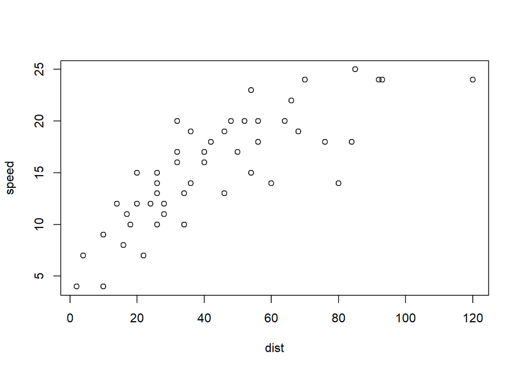

```r
library(mosaic)
library(ggplot2)
library(dplyr)
library(tidyverse)

plot(speed~dist, data = cars)
```

```r
cars.lm <- lm(speed ~ dist, data = cars)
summary(cars.lm)
```

```
##
## Call:
## lm(formula = speed ~ dist, data = cars)
##
## Residuals:
##     Min      1Q  Median      3Q     Max
## -7.5293 -2.1550  0.3615  2.4377  6.4179
##
## Coefficients:
##             Estimate Std. Error t value Pr(>|t|)
## (Intercept)  8.28391    0.87438   9.474 1.44e-12 ***
## dist         0.16557    0.01749   9.464 1.49e-12 ***
## ---
## Signif. codes:  0 '***' 0.001 '**' 0.01 '*' 0.05 '.' 0.1 ' ' 1
##
## Residual standard error: 3.156 on 48 degrees of freedom
## Multiple R-squared:  0.6511, Adjusted R-squared:  0.6438
## F-statistic: 89.57 on 1 and 48 DF,  p-value: 1.49e-12
```

```r
#this is the way we calculate our p-value by hand
#Pr(>\t\) just means that the probablility is two-tailed

2*pt(9.474, 48, lower.tail = FALSE)
```

```
## [1] 1.440903e-12
```

```r
#this is calculating the critical value. 0.25 is our alpha or level of significance
qt(1-0.25/2, 48)
```

```
## [1] 1.164442
```

```r
#This is the confidence interval equation and margin of error
#  b0 +or- t(1-a/2; n-2)S{b0}

8.28391 + qt(1-0.05/2, 48)*0.87438
```

```
## [1] 10.04197
```

```r
8.28391 - qt(1-0.05/2, 48)*0.87438
```

```
## [1] 6.525851
```

```r
confint(cars.lm)
```

```
##                 2.5 %     97.5 %
## (Intercept) 6.5258378 10.0419735
## dist        0.1303926  0.2007426
```

```r
#Also confint(cars.lm, level = (confidence interval))
#this is how to calculate the residuals

sum(cars.lm$residuals^2)
```

```
## [1] 478.0212
```

```r
sqrt(sum(cars.lm$residuals^2)/48)
```

```
## [1] 3.155753
```

```r
#prediction interval
predict(cars.lm, data.frame(dist=50), interval = "prediction")
```

```
##        fit      lwr      upr
## 1 16.56228 10.14933 22.97524
```

```r
predict(cars.lm, data.frame(dist=50), interval = "confidence")
```

```
##        fit     lwr      upr
## 1 16.56228 15.6316 17.49297
```

## Reading Points {40} Possible

### Section 2.1 {6}{ 5/6 }

### Section 2.2 {3}{ 3/3 }

### Section 2.3 {1}{ 1/1 }

### Section 2.4 {4}{ 3/4}

### Section 2.5 {6}{ 5/ 6}

### Section 2.6 {3}{ 3/3}

### Section 2.7 {8}{ 6/ 8}

### Section 2.8 {4}{ 3/ 4}

### Section 2.9 {3}{ 3/3 }

### Section 2.10 {2}{ 2/2 }

## Theory Points {33} Possible

### Problem 2.1 {1}{ / }

### Problem 2.2 {1}{ / }

### Problem 2.3 {1}{ / }

### Problem 2.9 {1}{ / }

### Problem 2.11 {1}{ / }

### Problem 2.12 {1}{ / }

### Problem 2.18 {1}{ / }

Hint: Read page 71

### Problem 2.19 {1}{ / }

### Problem 2.20 or 2.21 or 2.22 {1}{ / }

### Problem 2.33 {3}{ 3/3 }

1. $$H_0 = 0$$
   $$H_a neq 0$$

Full Model:
$$y_i = \beta_0 + \beta_1x_i + \epsilon_i$$
Reduced model:
$$y_i = \beta_0 +\epsilon_i$$

### Problem 2.51 {2}{ / }

### Problem 2.53 {4}{ / }

### Problem 2.66 {5}{ 3/5 }

```r
x <- c(4,8,12,16,20)

e <- rnorm(5, 0, sqrt(25))


y <- 20 + 4 * x + e

p2.66.lm <- lm(y~x)

b <- p2.66.lm$coefficients

print(b)
```

```
## (Intercept)           x
##   16.154218    4.280012
```

```r
predict(p2.66.lm, data.frame(x=10), interval = "confidence")
```

```
##        fit      lwr      upr
## 1 58.95434 53.06025 64.84843
```

R-Code Hint: rnorm(5, 0, sqrt(25))

### Exercise 2.55 {2}{ / }

### Exercise 2.57 {3}{ / }

### Exercise 2.61 {3}{ / }

## Application Points {53} Possible

[Data Files](http://www.stat.ufl.edu/~rrandles/sta4210/Rclassnotes/data/textdatasets/index.html)

### Problem 2.1 {1}{ / }

### Problem 2.4 {4}{ 4/4 }

```r
# Load the Data:
p1.19 <- read.table("https://netfiles.umn.edu/users/nacht001/www/nachtsheim/Kutner/Chapter%20%201%20Data%20Sets/CH01PR19.txt")

# Rewrite the column names to be "Y" and "X" to match the textbook:
colnames(p1.19) <- c("Y","X")

p1.19.lm <- lm(p1.19)

summary(p1.19.lm)
```

```
##
## Call:
## lm(formula = p1.19)
##
## Residuals:
##      Min       1Q   Median       3Q      Max
## -2.74004 -0.33827  0.04062  0.44064  1.22737
##
## Coefficients:
##             Estimate Std. Error t value Pr(>|t|)
## (Intercept)  2.11405    0.32089   6.588  1.3e-09 ***
## X            0.03883    0.01277   3.040  0.00292 **
## ---
## Signif. codes:  0 '***' 0.001 '**' 0.01 '*' 0.05 '.' 0.1 ' ' 1
##
## Residual standard error: 0.6231 on 118 degrees of freedom
## Multiple R-squared:  0.07262,    Adjusted R-squared:  0.06476
## F-statistic:  9.24 on 1 and 118 DF,  p-value: 0.002917
```

```r
confint(p1.19.lm, level = 0.99)
```

```
##                   0.5 %     99.5 %
## (Intercept) 1.273902675 2.95419590
## X           0.005385614 0.07226864
```

```r
print(confint(p1.19.lm, level = 0.99))
```

```
##                   0.5 %     99.5 %
## (Intercept) 1.273902675 2.95419590
## X           0.005385614 0.07226864
```

```r
qt(1-0.01/2, length(p1.19$X-2))
```

```
## [1] 2.617421
```

$H_0: \beta_1 = 0$ $H_a: \beta_1 \ne 0$

If |t*| <= t(1-$\alpha$/2; n-2), conclude $H_o$ If |t*| >= t(1-$\alpha$/2; n-2), conclude $H_a$

t* = 3.040

Our P-value is : 0.00292

### Problem 2.5 {4}{ 4/4 }

```r
# Load the Data:
p1.20 <- read.table("https://netfiles.umn.edu/users/nacht001/www/nachtsheim/Kutner/Chapter%20%201%20Data%20Sets/CH01PR20.txt")

# Rewrite the column names to be "Y" and "X" to match the textbook:
colnames(p1.20) <- c("Y","X")

p1.20.lm <- lm(p1.20)

summary(p1.20.lm)
```

```
##
## Call:
## lm(formula = p1.20)
##
## Residuals:
##      Min       1Q   Median       3Q      Max
## -22.7723  -3.7371   0.3334   6.3334  15.4039
##
## Coefficients:
##             Estimate Std. Error t value Pr(>|t|)
## (Intercept)  -0.5802     2.8039  -0.207    0.837
## X            15.0352     0.4831  31.123   <2e-16 ***
## ---
## Signif. codes:  0 '***' 0.001 '**' 0.01 '*' 0.05 '.' 0.1 ' ' 1
##
## Residual standard error: 8.914 on 43 degrees of freedom
## Multiple R-squared:  0.9575, Adjusted R-squared:  0.9565
## F-statistic: 968.7 on 1 and 43 DF,  p-value: < 2.2e-16
```

```r
qt(1-0.90/2, length(p1.20$X) - 2)
```

```
## [1] 0.1264057
```

1. It is estimated that there is an increased 15.04 for every printer that is serviced.
2. $H_0: \beta_1 = 0$ $H_a: \beta_1 \ne 0$

If |t*| <= t(1-$\alpha$/2; n-2), conclude $H_o$ If |t*| >= t(1-$\alpha$/2; n-2), conclude $H_a$

t* = 31/123

t = 0.1264

conclude $H_a$

3. Yes, because we conclude that there is an association between the variables, we can assume that for every printer serviced, the time increases.
4. We see that $\beta1$ is equal to 15.0352. This means that they are one minute over. The P-value is low, so we can assume that this is appropriate.
5. $\beta0$ doesn’t give any relevant information because we would have negative time used if that was the case and that’s impossible.

### Problem 2.7 {3}{ / }

```r
# Load the Data:
p1.22 <- read.table("https://netfiles.umn.edu/users/nacht001/www/nachtsheim/Kutner/Chapter%20%201%20Data%20Sets/CH01PR22.txt")

# Rewrite the column names to be "Y" and "X" to match the textbook:
colnames(p1.22) <- c("Y","X")
```

### Problem 2.10 {2}{ 2/2 }

1. It is appropriate because there are multiple times when the temperature could be set to 31 degrees
2. It depends on the size of the population. If we’re are sampling the entire U.S. population, I would say yes because there could be several families that would have the same income, but if it was just a city or region, I would say no.

c.Yes, because the x value will remain the same and we can have a confidence interval when there are multiple yi values for the same x value.

### Problem 2.13 {4}{ 3/4 }

```r
# Load the Data:
p1.19 <- read.table("https://netfiles.umn.edu/users/nacht001/www/nachtsheim/Kutner/Chapter%20%201%20Data%20Sets/CH01PR19.txt")

# Rewrite the column names to be "Y" and "X" to match the textbook:
colnames(p1.19) <- c("Y","X")

summary(p1.19.lm)
```

```
##
## Call:
## lm(formula = p1.19)
##
## Residuals:
##      Min       1Q   Median       3Q      Max
## -2.74004 -0.33827  0.04062  0.44064  1.22737
##
## Coefficients:
##             Estimate Std. Error t value Pr(>|t|)
## (Intercept)  2.11405    0.32089   6.588  1.3e-09 ***
## X            0.03883    0.01277   3.040  0.00292 **
## ---
## Signif. codes:  0 '***' 0.001 '**' 0.01 '*' 0.05 '.' 0.1 ' ' 1
##
## Residual standard error: 0.6231 on 118 degrees of freedom
## Multiple R-squared:  0.07262,    Adjusted R-squared:  0.06476
## F-statistic:  9.24 on 1 and 118 DF,  p-value: 0.002917
```

yi = 2.11405 + 0.03883 *28

ACT = 28 GPA = 3.20129

```r
confint(p1.19.lm)
```

```
##                  2.5 %     97.5 %
## (Intercept) 1.47859015 2.74950842
## X           0.01353307 0.06412118
```

```r
predict(p1.19.lm, data.frame(X=28), interval = "confidence")
```

```
##        fit      lwr      upr
## 1 3.201209 3.061384 3.341033
```

```r
predict(p1.19.lm, data.frame(X=28), interval = "prediction")
```

```
##        fit      lwr      upr
## 1 3.201209 1.959355 4.443063
```